# Regresiones y Correlaciones

# Introduccion

Para el ultimo tema del curso vamos a ver como calcular regresiones y hacer correlaciones lineales en RStudio. Muchas veces confundidas entre si las regresiones y las correlaciones son las tecnicas mas comunes para determinar si existe una relacion entre dos variables cuantitativas.

# Correlacion

Por un lado, la correlacion o mas propiamente dicho *el coeficiente de correlacion* (hay varios metodos el mas comun es el de Pearson) *r* cuantifica la fuerza con la cual dos variables estan correlacionadas. Al ser un coeficiente *r* no tiene unidades y sus valores oscilan entre $-1 =< r =< 1$. Valores cercano a 1 o -1 indican una fuerte relacion entre ambas variables y valores cercanas a 0 una relacion debil.

Las suposiciones para correr una correlacion de pearson son el nivel de las medidas que los pares esten relacionados, idealmente que no hayan outliers, y que la correlacion se vea linear

El nivel de las medidas en el caso de pearson se refiere a que ambas variables deben de ser continuas. Si una o ambas variables son ordinales entonces se debe de llevar acavo otro tipo de correlacion como Spearman.

```r
cor.test(flujosC$CH4.conc,flujosC$CO2.conc)
```

```
    Pearson's product-moment correlation

data:  flujosC$CH4.conc and flujosC$CO2.conc
t = -29.806, df = 28, p-value < 2.2e-16
alternative hypothesis: true correlation is not equal to 0
95 percent confidence interval:
 -0.9927299 -0.9675457
sample estimates:
       cor
-0.9846045
```

# Regresion

Una vez que sabemos si dos variables cuantitativas estan correlacionadas el siguiente paso es expresar esta relacion en la forma de una ecuacion. Usando esta ecuacion uno podria calcular una de las variables si se sabe la otra

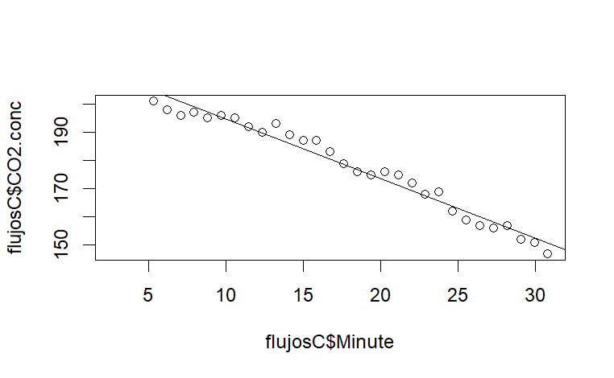

**CO2= -2.10941x+215.72**

En la ecuacion la pendiente nos senala que cada minuto el CO2 disminuye *-2.1 ppm*

```r
summary(lm(flujosC$CH4.conc ~ flujosC$Minute))
```

```
Call:
lm(formula = flujosC$CH4.conc ~ flujosC$Minute)

Residuals:
     Min       1Q   Median       3Q      Max
-0.32139 -0.09679 -0.00120  0.08650  0.28302

Coefficients:
                Estimate Std. Error t value Pr(>|t|)
(Intercept)    12.292380   0.058288   210.9   <2e-16 ***
flujosC$Minute  0.413679   0.003117   132.7   <2e-16 ***
---
Signif. codes:
0 ‘***’ 0.001 ‘**’ 0.01 ‘*’ 0.05 ‘.’ 0.1 ‘ ’ 1

Residual standard error: 0.15 on 31 degrees of freedom
Multiple R-squared:  0.9982,    Adjusted R-squared:  0.9982
F-statistic: 1.762e+04 on 1 and 31 DF,  p-value: < 2.2e-16
```

## Ejercicio

Busquen o creen un set de datos en que se puede analizar una correlacion y regresion lineal. JUSTIFIQUE SU RESPUESTA

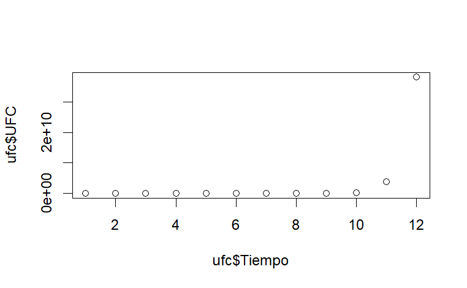